# **Project - Classification and Hypothesis Testing: Hotel Booking Cancellation Prediction**

#### **Visualizing the Decision Tree**

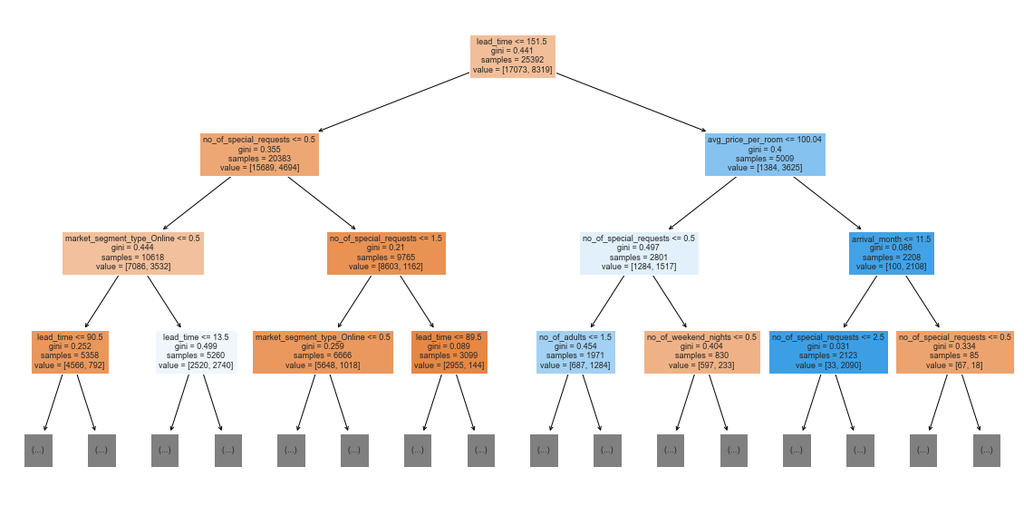

```python
feature_names = list(X_train.columns)
plt.figure(figsize=(20, 10))
out = tree.plot_tree(
    estimator,max_depth=3,
    feature_names=feature_names,
    filled=True,
    fontsize=9,
    node_ids=False,
    class_names=None,
)
# below code will add arrows to the decision tree split if they are missing
for o in out:
    arrow = o.arrow_patch
    if arrow is not None:
        arrow.set_edgecolor("black")
        arrow.set_linewidth(1)
plt.show()
```

#### **Question 6.5: What are some important features based on the tuned decision tree? (1 Mark)**

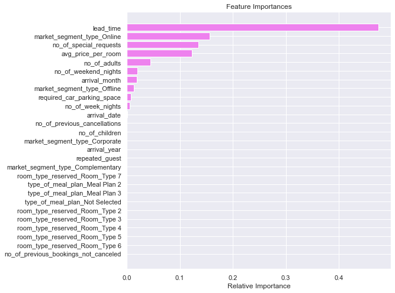

```python
# Remove _________ and complete the code

# Importance of features in the tree building

importances = estimator.feature_importances_
indices = np.argsort(importances)

plt.figure(figsize=(8, 8))
plt.title("Feature Importances")
plt.barh(range(len(indices)), importances[indices], color="violet", align="center")
plt.yticks(range(len(indices)), [feature_names[i] for i in indices])
plt.xlabel("Relative Importance")
plt.show()
```

**Write your answers here:**_****

Lead_time, market_segment_type_online, and no_of_special_requests are the most important features of the Decision Tree model. The Lead_time variable shows the highest importance in the model.

### **Question 7: Random Forest (4 Marks)**

#### **Question 7.1: Build a Random Forest Model (1 Mark)**

```python
# Remove _________ and complete the code

rf_estimator = RandomForestClassifier( random_state = 1)

rf_estimator.fit(X_train, y_train)
```

```
RandomForestClassifier(random_state=1)
```

#### **Question 7.2: Check the performance of the model on the train and test data (2 Marks)**

```
              precision    recall  f1-score   support

           0       0.99      1.00      1.00     17073
           1       1.00      0.99      0.99      8319

    accuracy                           0.99     25392
   macro avg       0.99      0.99      0.99     25392
weighted avg       0.99      0.99      0.99     25392
```

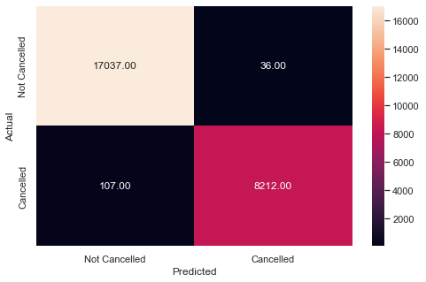

```python
# Remove _________ and complete the code

y_pred_train_rf = rf_estimator.predict(X_train)

metrics_score(y_train, y_pred_train_rf)
```

**Write your answers here:**_****

F1-score is 1.00, the recall is .99 and the precision is .99. The trainset shows a great accuracy of .99.

```
              precision    recall  f1-score   support

           0       0.91      0.95      0.93      7317
           1       0.88      0.80      0.84      3566

    accuracy                           0.90     10883
   macro avg       0.90      0.88      0.88     10883
weighted avg       0.90      0.90      0.90     10883
```

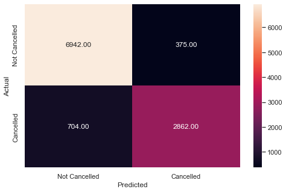

```python
# Remove _________ and complete the code

y_pred_test_rf = rf_estimator.predict(X_test)

metrics_score(y_test, y_pred_test_rf)
```

**Write your answers here:**_****

#### **Question 7.3: What are some important features based on the Random Forest? (1 Mark)**

Let's check the feature importance of the Random Forest

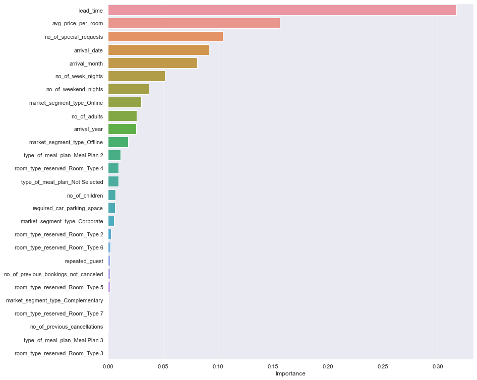

```python
# Remove _________ and complete the code

importances = rf_estimator.feature_importances_

columns = X.columns

importance_df = pd.DataFrame(importances, index = columns, columns = ['Importance']).sort_values(by = 'Importance', ascending = False)

plt.figure(figsize = (13, 13))

sns.barplot(importance_df.Importance, importance_df.index)
```

**Write your answers here:**_****

Base on the random forest model the importance features are lead_time, Avg_price_per_room, no_of_special_requests and arrival_date

### **Question 8: Conclude ANY FOUR key takeaways for business recommendations (4 Marks)**

**Write your answers here:**_****

In the analysis shows the amount of lead_time shows the high importance of a customer booking a hotel room will be cancelled. The company should focus on the market_segment_type of complementary. It show no cancelation of room with using the marketing segment type. Increasing on improving the online market_segment_type because if the company is promoting deals they can continue on using online marketing to attract customers from there.

- The company should focus on the customers that are repeated guests because it shows that repeated guests are less likely to cancel their booking of rooms.
- Guests who book for staying at the hotel for more than 10 days are more likely to cancel.
- The company should call the customer that booked the hotel room and ask if the customer has any special request to lower down cancellation do to special request of rooms.
- In the study, the avg_room_price shows as one of the highest importantace, if you have deals you should promote them to customers to lower the cost.

Conclusion:

```
precision    recall  f1-score   support

       0       0.82      0.89      0.85      7317
       1       0.73      0.60      0.66      3566

accuracy                           0.79     10883
```

```
  precision    recall  f1-score   support

       0       0.82      0.90      0.86      7317
       1       0.74      0.61      0.67      3566

accuracy                           0.80     10883
```

[output not shown]

```
precision    recall  f1-score   support

       0       0.85      0.93      0.89      7317
       1       0.82      0.67      0.74      3566

accuracy                           0.84     10883
```

Random Forest

```
          precision    recall  f1-score   support

       0       0.91      0.95      0.93      7317
       1       0.88      0.80      0.84      3566

accuracy                           0.90     10883
```